# Weather Event Analysis at USA.

HyunSik Shim

Monday, Feburary 16 2015

This is my report document for Peer Assessment 2 in the Reproducible Research course. In it, I provide answers, in the form and figures and data, to the questions in the assignment.

I also include the R code that produces the answers. Storms and other severe weather events can cause both *public health and economic problems* for communities and municipalities. Many severe events can result in fatalities, injuries, and property damage, and preventing such outcomes to the extent possible is a key concern.

I will process calculate public health and economic problems cuased by weather event using **U.S. National Oceanic and Atmospheric Administration’s (NOAA) storm database**.

## System Setting and Data Processing

1. Before data processing, we have to set system according to OS and memory and install packages.

```r
## We have to set memeory size as 4GB for Windows 32 bit system.
## memory.limit(size = 4080)
library("plyr")
## I have to set locale as English for processing data
## because errror reading csv file in Korean.
Sys.setlocale("LC_ALL", locale = "English_United States")
```

```
## [1] "LC_COLLATE=English_United States.1252;LC_CTYPE=English_United States.1252;LC_MONETARY=English_United States.1252;LC_NUMERIC=C;LC_TIME=English_United States.1252"
```

2. Data read and Extract meaningful data.

```r
StormData<-read.csv("repdata-data-StormData.csv.bz2",header=TRUE,stringsAsFactors = TRUE)
CleanData <- StormData[,c("STATE","EVTYPE","FATALITIES","INJURIES","PROPDMG","PROPDMGEXP","CROPDMG","CROPDMGEXP")]
str(CleanData)
```

```
## 'data.frame':    902297 obs. of  8 variables:
##  $ STATE     : Factor w/ 72 levels "AK","AL","AM",..: 2 2 2 2 2 2 2 2 2 2 ...
##  $ EVTYPE    : Factor w/ 985 levels "   HIGH SURF ADVISORY",..: 834 834 834 834 834 834 834 834 834 834 ...
##  $ FATALITIES: num  0 0 0 0 0 0 0 0 1 0 ...
##  $ INJURIES  : num  15 0 2 2 2 6 1 0 14 0 ...
##  $ PROPDMG   : num  25 2.5 25 2.5 2.5 2.5 2.5 2.5 25 25 ...
##  $ PROPDMGEXP: Factor w/ 19 levels "","-","?","+",..: 17 17 17 17 17 17 17 17 17 17 ...
##  $ CROPDMG   : num  0 0 0 0 0 0 0 0 0 0 ...
##  $ CROPDMGEXP: Factor w/ 9 levels "","?","0","2",..: 1 1 1 1 1 1 1 1 1 1 ...
```

3. To solve 2 main questions, I make new 3 variables for public health and economic impacts

```r
TinyData<-mutate(CleanData,Total_Fatalities=FATALITIES+INJURIES)

##fucntion for calculating damage using DMG and DMGEXP variable
## we will use PROPDMG and CROPDMG
damage_measure<-function(data_dmg,data_exp) {
  Total_value=data_dmg*ifelse(data_exp=="H"|data_exp=="h",100,0)
  Total_value=Total_value+data_dmg*ifelse(data_exp=="K"| data_exp=="k",1000,0)
  Total_value=Total_value+data_dmg*ifelse(data_exp=="M"| data_exp=="m",1000000,0)
  Total_value=Total_value+data_dmg*ifelse(data_exp=="B"| data_exp=="b",1000000000,0)

  Total_value=Total_value+ifelse(data_exp=="1",data_dmg*1000+100,0)
  Total_value=Total_value+ifelse(data_exp=="2",data_dmg*1000+200,0)
  Total_value=Total_value+ifelse(data_exp=="3",data_dmg*1000+300,0)
  Total_value=Total_value+ifelse(data_exp=="4",data_dmg*1000+400,0)
  Total_value=Total_value+ifelse(data_exp=="5",data_dmg*1000+500,0)
  Total_value=Total_value+ifelse(data_exp=="6",data_dmg*1000+600,0)
  Total_value=Total_value+ifelse(data_exp=="7",data_dmg*1000+700,0)
  Total_value=Total_value+ifelse(data_exp=="8",data_dmg*1000+800,0)
  Total_value=Total_value+ifelse(data_exp=="9",data_dmg*1000+900,0)
  Total_value=Total_value+ifelse(data_exp=="?" |data_exp=="+",data_dmg,0)
  Toal_value=Total_value+ifelse(data_exp=="" |data_exp=="-",data_dmg,0)
  return(Total_value)

}

prop_damage<-damage_measure(TinyData$PROPDMG,TinyData$PROPDMGEXP)
crop_damage<-damage_measure(TinyData$CROPDMG,TinyData$CROPDMGEXP)

TinyData<-cbind(TinyData,as.data.frame(prop_damage))
TinyData<-cbind(TinyData,as.data.frame(crop_damage))
str(TinyData)
```

```
## 'data.frame':    902297 obs. of  11 variables:
##  $ STATE           : Factor w/ 72 levels "AK","AL","AM",..: 2 2 2 2 2 2 2 2 2 2 ...
##  $ EVTYPE          : Factor w/ 985 levels "   HIGH SURF ADVISORY",..: 834 834 834 834 834 834 834 834 834 834 ...
##  $ FATALITIES      : num  0 0 0 0 0 0 0 0 1 0 ...
##  $ INJURIES        : num  15 0 2 2 2 6 1 0 14 0 ...
##  $ PROPDMG         : num  25 2.5 25 2.5 2.5 2.5 2.5 2.5 25 25 ...
##  $ PROPDMGEXP      : Factor w/ 19 levels "","-","?","+",..: 17 17 17 17 17 17 17 17 17 17 ...
##  $ CROPDMG         : num  0 0 0 0 0 0 0 0 0 0 ...
##  $ CROPDMGEXP      : Factor w/ 9 levels "","?","0","2",..: 1 1 1 1 1 1 1 1 1 1 ...
##  $ Total_Fatalities: num  15 0 2 2 2 6 1 0 15 0 ...
##  $ prop_damage     : num  25000 2500 25000 2500 2500 2500 2500 2500 25000 25000 ...
##  $ crop_damage     : num  0 0 0 0 0 0 0 0 0 0 ...
```

## Main Questions and Results

1. Across the United States, which types of events are most harmful with respect to population health?

```r
Population_health<-ddply(TinyData,.(EVTYPE),summarise, Total=sum(Total_Fatalities))
Max_Value<-Population_health[which.max(Population_health$Total),1]
abstract_data<-head(arrange(Population_health,desc(Total),EVTYPE),10)
abstract_data
```

```
##               EVTYPE Total
## 1            TORNADO 96979
## 2     EXCESSIVE HEAT  8428
## 3          TSTM WIND  7461
## 4              FLOOD  7259
## 5          LIGHTNING  6046
## 6               HEAT  3037
## 7        FLASH FLOOD  2755
## 8          ICE STORM  2064
## 9  THUNDERSTORM WIND  1621
## 10      WINTER STORM  1527
```

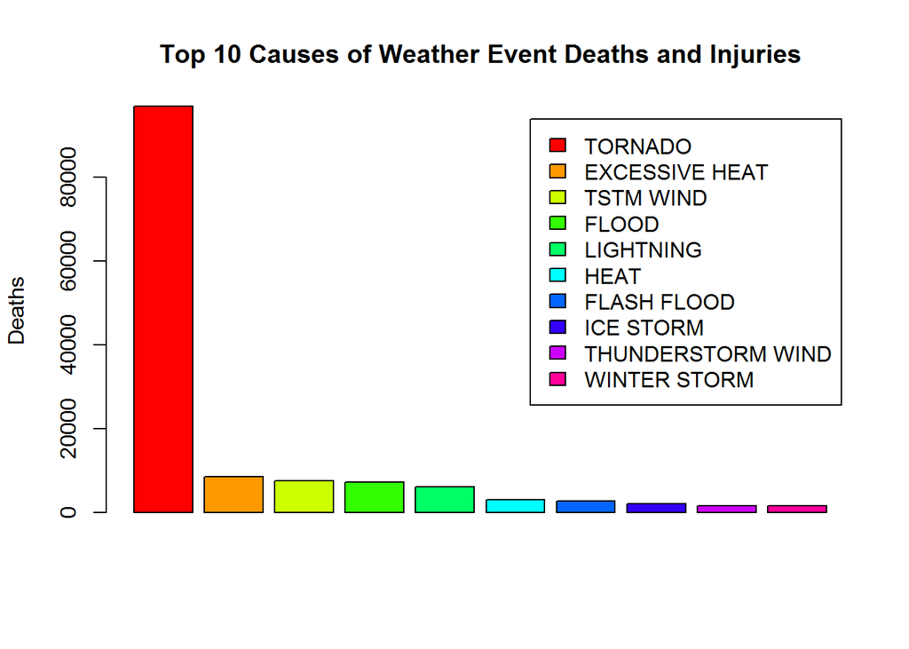

```r
barplot(abstract_data$Total,col=rainbow(10),main="Top 10 Causes of Weather Event Deaths and Injuries",ylab="Deaths", legend=abstract_data$EVTYPE)
```

```r
Population_health_injuries<-ddply(TinyData,.(EVTYPE),summarise, Total=sum(INJURIES))
abstract_data_injuries<-head(arrange(Population_health_injuries,desc(Total),EVTYPE),10)
abstract_data_injuries
```

```
##               EVTYPE Total
## 1            TORNADO 91346
## 2          TSTM WIND  6957
## 3              FLOOD  6789
## 4     EXCESSIVE HEAT  6525
## 5          LIGHTNING  5230
## 6               HEAT  2100
## 7          ICE STORM  1975
## 8        FLASH FLOOD  1777
## 9  THUNDERSTORM WIND  1488
## 10              HAIL  1361
```

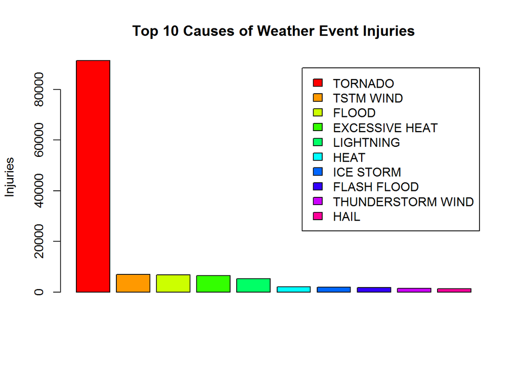

```r
barplot(abstract_data_injuries$Total,col=rainbow(10),main="Top 10 Causes of Weather Event Injuries",ylab="Injuries", legend=abstract_data_injuries$EVTYPE)
```

- TORNADO are most harmful with respect to population health.
- Total 9.6979 × 10<sup>4</sup> people are killed or wounded by TORNADO.
2. Across the United States, which types of events have the greatest economic consequences?

```r
damages<-ddply(TinyData,.(EVTYPE),summarise, Total_damage=sum(prop_damage)+sum(crop_damage))
Max_Value_damage<-damages[which.max(damages$Total_damage),1]
abstract_data_second<-head(arrange(damages,desc(Total_damage),EVTYPE),10)
abstract_data_second
```

```
##               EVTYPE Total_damage
## 1              FLOOD    1.503e+11
## 2  HURRICANE/TYPHOON    7.191e+10
## 3            TORNADO    5.735e+10
## 4        STORM SURGE    4.332e+10
## 5               HAIL    1.876e+10
## 6        FLASH FLOOD    1.756e+10
## 7            DROUGHT    1.502e+10
## 8          HURRICANE    1.461e+10
## 9        RIVER FLOOD    1.015e+10
## 10         ICE STORM    8.967e+09
```

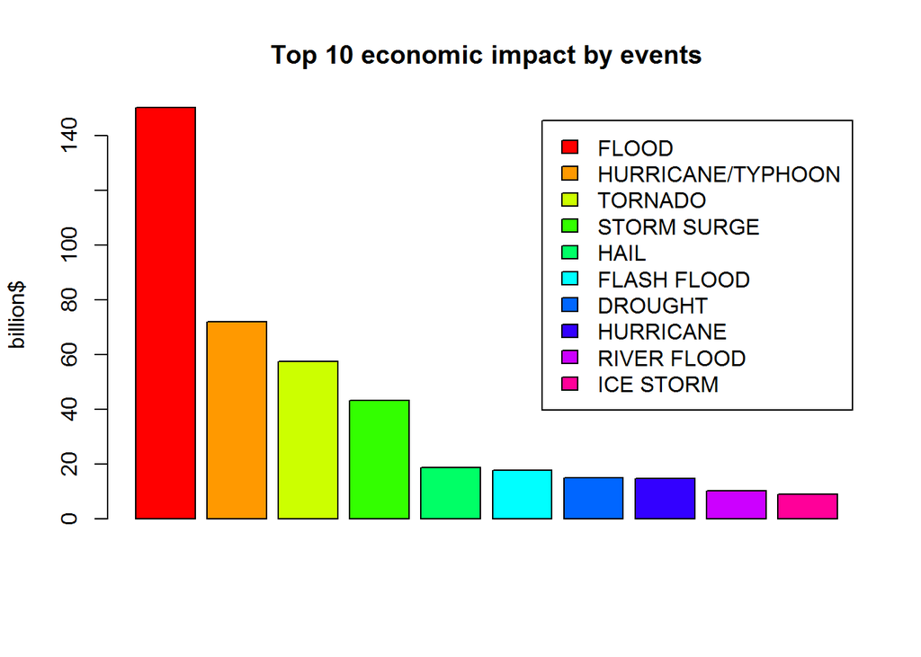

```r
barplot(abstract_data_second$Total_damage/1e9,col=rainbow(10),main="Top 10 economic impact by events",ylab="billion$", legend=abstract_data_second$EVTYPE)
```

- FLOOD are the greatest economic consequences across the United States.
- The United States lost up to 150.3197 billion$ by flood.